# Regularization with `glmnet`

This is tightly based on the code used by Hastie and Tibshirani in their Stanford OpenEdX class, [Statistical Learning](http://online.stanford.edu/course/statistical-learning-winter-2014). Hastie and Tibsharini are prime creators of these techniques, coders of the `glmnet` package, the authors of the classic? *Elements of Statistical Learning*. You can get quite a lot more about `glmnet` in the [glmnet vignette](http://www.stanford.edu/~hastie/glmnet/glmnet_alpha.html).

### Setup

```r
library(ISLR)
summary(Hitters)
```

```
##      AtBat          Hits         HmRun           Runs
##  Min.   : 16   Min.   :  1   Min.   : 0.0   Min.   :  0.0
##  1st Qu.:255   1st Qu.: 64   1st Qu.: 4.0   1st Qu.: 30.2
##  Median :380   Median : 96   Median : 8.0   Median : 48.0
##  Mean   :381   Mean   :101   Mean   :10.8   Mean   : 50.9
##  3rd Qu.:512   3rd Qu.:137   3rd Qu.:16.0   3rd Qu.: 69.0
##  Max.   :687   Max.   :238   Max.   :40.0   Max.   :130.0
##
##       RBI            Walks           Years           CAtBat
##  Min.   :  0.0   Min.   :  0.0   Min.   : 1.00   Min.   :   19
##  1st Qu.: 28.0   1st Qu.: 22.0   1st Qu.: 4.00   1st Qu.:  817
##  Median : 44.0   Median : 35.0   Median : 6.00   Median : 1928
##  Mean   : 48.0   Mean   : 38.7   Mean   : 7.44   Mean   : 2649
##  3rd Qu.: 64.8   3rd Qu.: 53.0   3rd Qu.:11.00   3rd Qu.: 3924
##  Max.   :121.0   Max.   :105.0   Max.   :24.00   Max.   :14053
##
##      CHits          CHmRun          CRuns           CRBI
##  Min.   :   4   Min.   :  0.0   Min.   :   1   Min.   :   0.0
##  1st Qu.: 209   1st Qu.: 14.0   1st Qu.: 100   1st Qu.:  88.8
##  Median : 508   Median : 37.5   Median : 247   Median : 220.5
##  Mean   : 718   Mean   : 69.5   Mean   : 359   Mean   : 330.1
##  3rd Qu.:1059   3rd Qu.: 90.0   3rd Qu.: 526   3rd Qu.: 426.2
##  Max.   :4256   Max.   :548.0   Max.   :2165   Max.   :1659.0
##
##      CWalks       League  Division    PutOuts        Assists
##  Min.   :   0.0   A:175   E:157    Min.   :   0   Min.   :  0.0
##  1st Qu.:  67.2   N:147   W:165    1st Qu.: 109   1st Qu.:  7.0
##  Median : 170.5                    Median : 212   Median : 39.5
##  Mean   : 260.2                    Mean   : 289   Mean   :106.9
##  3rd Qu.: 339.2                    3rd Qu.: 325   3rd Qu.:166.0
##  Max.   :1566.0                    Max.   :1378   Max.   :492.0
##
##      Errors          Salary       NewLeague
##  Min.   : 0.00   Min.   :  67.5   A:176
##  1st Qu.: 3.00   1st Qu.: 190.0   N:146
##  Median : 6.00   Median : 425.0
##  Mean   : 8.04   Mean   : 535.9
##  3rd Qu.:11.00   3rd Qu.: 750.0
##  Max.   :32.00   Max.   :2460.0
##                  NA's   :59
```

There are some missing values here, so before we proceed we will remove them:

```r
Hitters=na.omit(Hitters)
with(Hitters,sum(is.na(Salary)))
```

```
## [1] 0
```

### Ridge Regression (L2 penalty) and the Lasso (L1 penalty)

We will use the package `glmnet`, which does not use the model formula language, so we will set up an `x` and `y`.

```r
library(glmnet)
x=model.matrix(Salary ~ . -1, data=Hitters)
y=Hitters$Salary
```

First we will fit a ridge regression model. This is achieved by calling `glmnet` with `alpha=0`. (The parameter $\alpha$ balances penalties for elastic net regularization.)

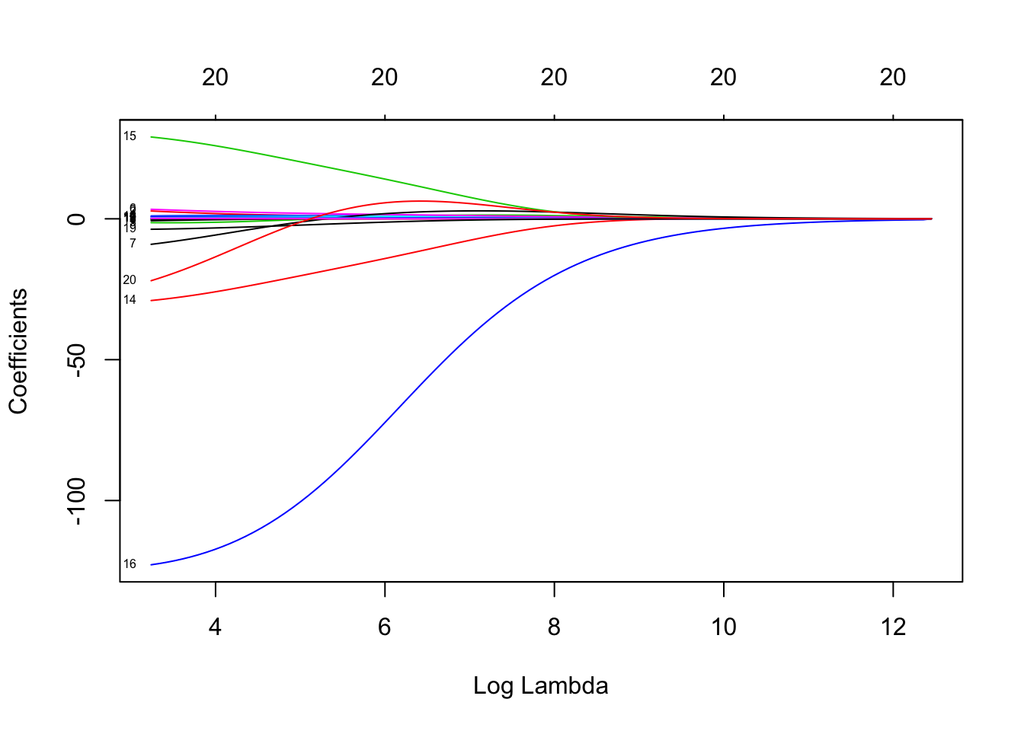

```r
fit.ridge=glmnet(x, y, alpha=0)
plot(fit.ridge, xvar="lambda", label=TRUE)
```

As shown in the plot, `glmnet` doesn’t just fit for one value of $\lambda$, but for many. The model `fit.ridge` now contains coefficients for 100 models, and using it with `predict` will produce 100 predictions for each data row. You could choose a value yourself, but there is also a `cv.glmnet` function which will use internal cross-validation to help select the parameter $\lambda$. The parameter `nfolds` defaults to ten but is included for illustrative purposes.

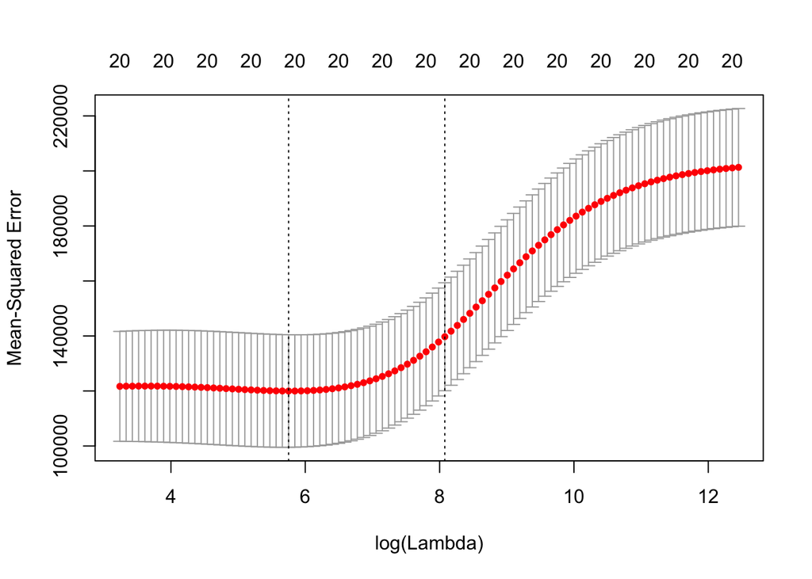

```r
set.seed(102)
cv.ridge=cv.glmnet(x, y, alpha=0, nfolds=10)
plot(cv.ridge)
```

The model `cv.ridge` also includes a lot of coefficients, but by default it will behave like the model chosen with cross-validation performance close to the minimum (with a standard deviation) but on the simpler side. You can specify this explicitly using `s="lambda.1se"` as an argument to `coef()` or `predict()`, for example. To get the actual minimum, use `s="lambda.min"`.

Now we fit a lasso model; for this we use the default `alpha=1`.

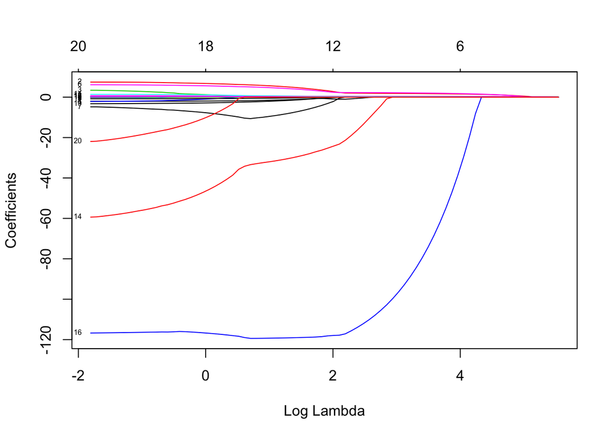

```r
fit.lasso=glmnet(x, y)
plot(fit.lasso, xvar="lambda", label=TRUE)
```

Notice that L1 regularization (the lasso) tends to set coefficients to exactly zero. The model semantics are still the same. As before, we can use `cv.glmnet`:

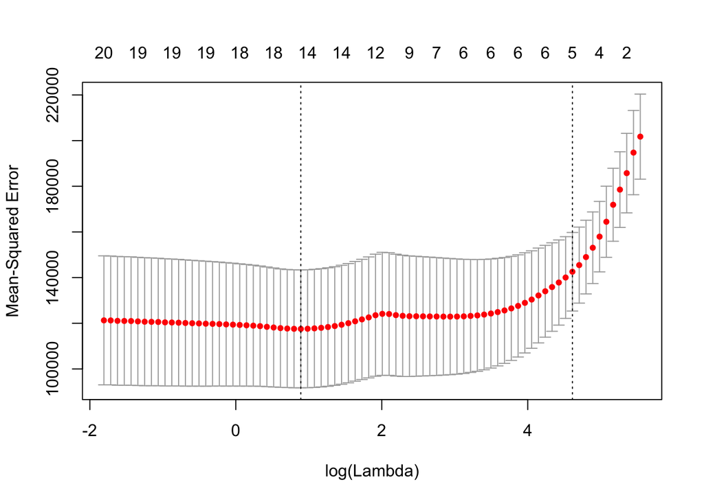

```r
set.seed(42)
cv.lasso=cv.glmnet(x, y, nfolds=10)
plot(cv.lasso)
```

```r
coef(cv.lasso)
```

```
## 21 x 1 sparse Matrix of class "dgCMatrix"
##                     1
## (Intercept) 2.221e+02
## AtBat       .
## Hits        1.129e+00
## HmRun       .
## Runs        .
## RBI         .
## Walks       1.172e+00
## Years       .
## CAtBat      .
## CHits       .
## CHmRun      .
## CRuns       1.147e-01
## CRBI        3.085e-01
## CWalks      .
## LeagueA     .
## LeagueN     .
## DivisionW   .
## PutOuts     1.763e-03
## Assists     .
## Errors      .
## NewLeagueN  .
```

`glmnet` uses optimizations to quickly generate a lot of results. `cv.glmnet` does an internal one-dimensional *grid search* to choose a value for $\lambda$. This could be extended to a grid search over $\alpha$ and $\lambda$ as well.